# Lab 3: Randomization-based inference

Collin Fabian

2/10/2021

**Introuduction**  
For this lab we will be observing whether an individual is more impressionable to others when communicating through audio or text. We will be examining the data from Schroeder and Epley’s 2015 experiment. In their experiment, the researchers gathered 39 professional recruiters employed at Fortune 500 companies to serve as participants in the experiment. Each recruiter was randomly assigned to either listen to an audio recording of the job pitch or read a trasncript of the job pitch. After hearing or reading the pitch, the participants rated the job candidate in three areas: intelligence, competence, and thoughtfulness. Ratings for each area were measured on a Likert scale from 0 (very low) to 10 (very high). These ratings were then averaged to create a single measure of the job candidate’s intellect, with higher scores indicating the recruiters rated the candidates as higher in intellect. The participants also rated their overall impression of the job candidate (a composite of two items measuring positive and negative impressions). Finally, the participants indicated how likely they would be to recommend hiring the job candidate.

**Exercise 1**  
We can first load the data and observe the first few entries.

```r
se15 = read.csv("https://bit.ly/255lab3", stringsAsFactors = T)
head(se15, n=5)
```

|  | condition | age | gender | Intellect_Rating | Impression_Rating | Hire_Rating |
| --- | --- | --- | --- | --- | --- | --- |
| 1 | audio | 29 | 2 | 6.000000 | 7.000000 | 6 |
| 2 | audio | 27 | 2 | 5.666667 | 4.666667 | 4 |
| 3 | audio | 27 | 2 | 6.000000 | 8.333333 | 5 |
| 4 | text | 40 | 2 | 3.333333 | 4.666667 | 4 |
| 5 | text | 32 | 2 | 1.000000 | 1.333333 | 1 |

Since our goal in this case is to compare groups, we will need to visualize our data using bivariate plots. We can use the ‘mosaic’ package to view the distribution of Impression_Rating across the two conditions.

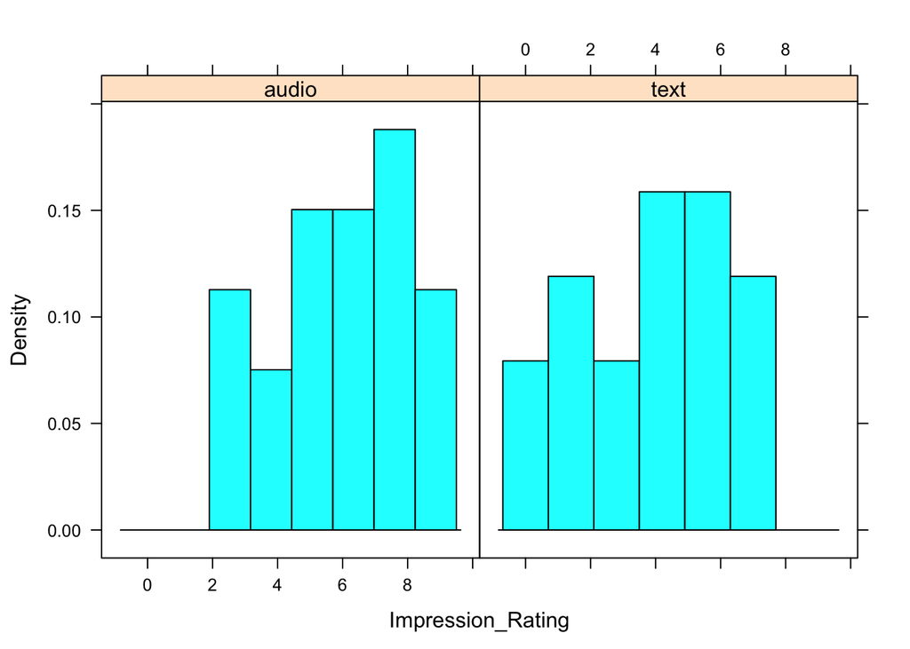

```r
histogram(~Impression_Rating | condition, data=se15)
```

We can also use boxplots to visualize the two distributions.

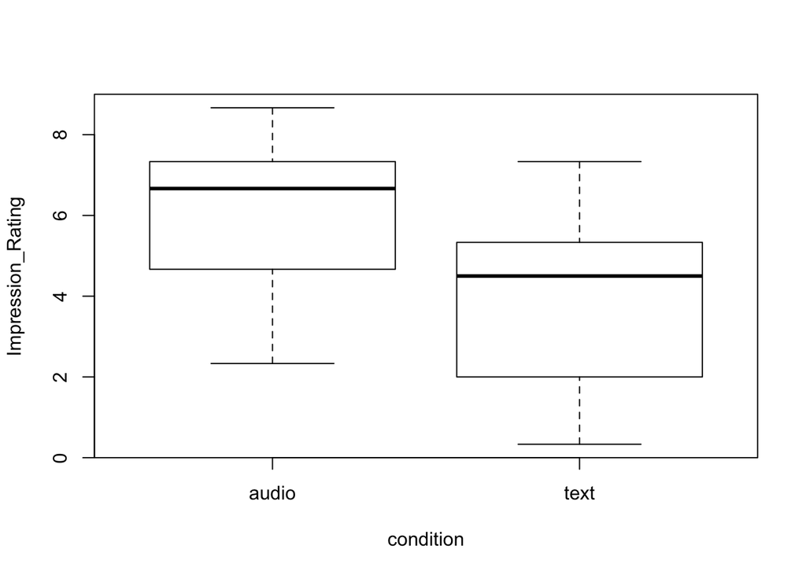

```r
boxplot(Impression_Rating~condition, data=se15)
```

Taking an intial look, it appears that the audio scores for Impression_Rating tend to be higher than the text scores. However, we must dive deeper in order to make confident conclusions.  
In order to make conclusions about the **average treatment effect (ATE)**, we must estimate the **population parameter**.  
To get this estimation, we can naturally use the difference in group means of the ‘audio’ and ‘text’ conditions as our estimator. Below we can view our sample means.

```r
tapply(se15$Impression_Rating, se15$condition, FUN = mean)
```

```
##    audio     text
## 5.968254 4.074074
```

We can see that the initial estimation for the causal effect audio compared to text is T=5.9683-4.0741=1.8942

```r
table(se15$condition)
```

```
##
## audio  text
##    21    18
```

**Randomization Test**  
To perform our randomization test, we must find the number of possible randomizations. This is done using the ‘choose’ function, where 39=# total participants and 21=# assigned to treatment ‘audio’.

```r
choose(39, 21)
```

```
## [1] 62359143990
```

We can now use the following code to perform a randomization test across 1,000 simulations.

```r
set.seed(123)
possible.diffs = c() # create vector to store results
n.sim = 1000
for (j in 1:n.sim){
  new.samp = sample(se15$condition) # take new randomization
  mean.audio = mean(se15$Impression_Rating[new.samp=="audio"])
  mean.text = mean(se15$Impression_Rating[new.samp=="text"])
  possible.diffs[j] = mean.audio-mean.text
}
```

Now we will visualize our randomization distribution. We will create a histogram that shows the difference in sample means that we could have attained using potentially different assignments of units to treatment, given that there is no average treatment effect at the population level (aka T=0).

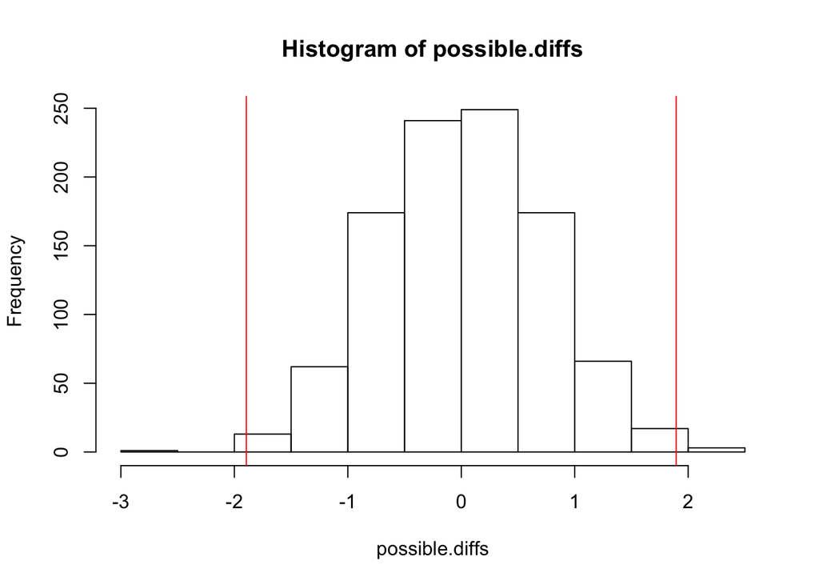

```r
hist(possible.diffs, breaks=15)
abline(v=1.8942, col="red")
abline(v=-1.8942, col="red")
```

We are now left with the question: how likely are we to get a sample difference in means of T=1.8942 if the poulation difference in means is in fact T=0? We can answer this question by obtaining our **randomization p-value**, which is simply the percentage of sample mean differences in our randomization distribution that are more extreme than 1.8942. We can use the following code to find the number of values in our distribution more extreme than 1.8942.

```r
sum(abs(possible.diffs)>1.8942)
```

```
## [1] 7
```

Therefore, our randomization p-value = 7/1000 = 0.007. Since our p-value is less than our benchmark of 0.05, we can reject the randomization null hypothesis that states that the true mean difference between conditions is zero. This means that we have statistically significant evidence to show that the average treatment effect of the conditions ‘audio’ and ‘text’ on Impression Rating differ at a population level. In the context of the real world, it means that an employee will, on average, be more impressionable to an employer if that employer hears the employee’s job pitch via audio as compared to text.  
Lastly, we will verify our results with the same randomization test using the ‘perm’ package.

```r
permTS(Impression_Rating~condition,data=se15)
```

```
##
##  Permutation Test using Asymptotic Approximation
##
## data:  Impression_Rating by condition
## Z = 2.616, p-value = 0.008897
## alternative hypothesis: true mean condition=audio - mean condition=text is not equal to 0
## sample estimates:
## mean condition=audio - mean condition=text
##                                    1.89418
```

As we can see, the results of this randomization test futher confirm the results of our own.

**Exercise 2**  
Now, we will perform the same randomization test for the difference in means based on condition with a new measurement variable ‘Hire_Rating’.  
Again, we will use bivariate plots to visually compare the distributions of Hire_Rating across the two conditions

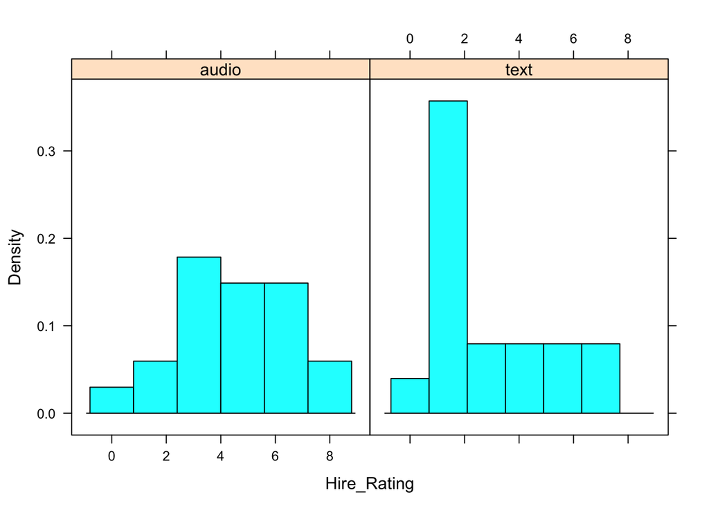

```r
histogram(~Hire_Rating | condition, data=se15)
```

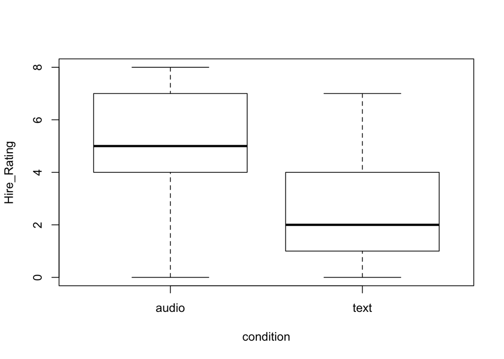

```r
boxplot(Hire_Rating~condition, data=se15)
```

```r
tapply(se15$Hire_Rating, se15$condition, mean)
```

```
##    audio     text
## 4.714286 2.888889
```

We can see that the initial estimation for the causal effect audio compared to text is T=4.7143-2.8889=1.8254.  
**Randomization Test**  
We may now perform the same randomization test as before.

```r
set.seed(123)
possible.diffs = c() # create vector to store results
n.sim = 1000
for (j in 1:n.sim){
  new.samp = sample(se15$condition) # take new randomization
  mean.audio = mean(se15$Hire_Rating[new.samp=="audio"])
  mean.text = mean(se15$Hire_Rating[new.samp=="text"])
  possible.diffs[j] = mean.audio-mean.text
}
```

Next is to visualize our randomization distribution. We will again create a histogram that shows the difference in sample means that we could have attained using potentially different assignments of units to treatment, given that there is no average treatment effect at the population level (aka T=0).

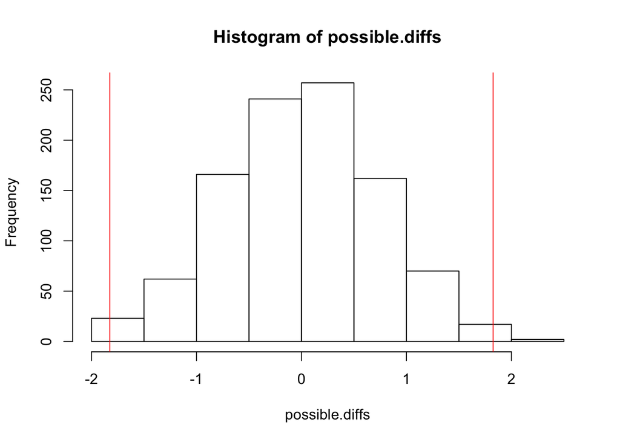

```r
hist(possible.diffs, breaks=15)
abline(v=1.8254, col="red")
abline(v=-1.8254, col="red")
```

Finally, we can obtain our **randomization p-value** by finding the percentage of sample mean differences in our randomization distribution that are more extreme than 1.8245. We can use the following code to find the number of values in our distribution more extreme than 1.8245.

```r
sum(abs(possible.diffs)>1.8254)
```

```
## [1] 7
```

```r
permTS(Hire_Rating~condition,data=se15)
```

```
##
##  Permutation Test using Asymptotic Approximation
##
## data:  Hire_Rating by condition
## Z = 2.4387, p-value = 0.01474
## alternative hypothesis: true mean condition=audio - mean condition=text is not equal to 0
## sample estimates:
## mean condition=audio - mean condition=text
##                                   1.825397
```

As we can see, the results of this randomization test futher confirm the results of our own.